# Properties of exponential distribution

6/25/2017

## Introduction

- This app describes the properties of an exponential distribution.
- The user inputs the rate parameter $\lambda$ and the app draws samples from the exponential distribution and plots the histogram.
- The app also calculates the distribution of the mean of samples drawn from the exponential distribution
- Note: This is different from the taking a large number of draws from the exponential distribution (as shown in the plot in slide #3 which looks exponential).

## Exponential distribution

A random variable is said to follow an exponential distribution with rate $\lambda$ is the associated probablity density is
$$P(x) = \lambda \exp(-\lambda x)$$
and it is defined for $x>0$. It describes the times between events in a Poisson process i.e., a process in which the events occur continuously and independently at a constant average rate $\lambda$.

If $X$ is a random variable with this density, then the expected values of the mean and standard deviation are both $1/\lambda$.

## Drawing samples

A histogram of 1000 draws from this distribution is given below:

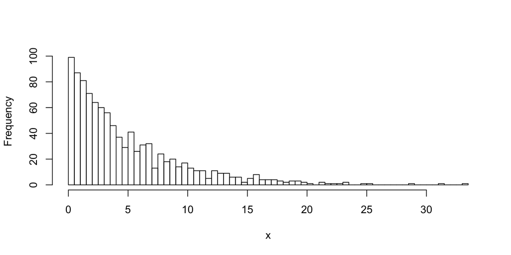

## Sample average of the mean

Now let’s sample $n = 40$ random variables from this distribution, find its average and repeat the simulation 1000 times. The sample average of the mean and its sample variance can be calculated.

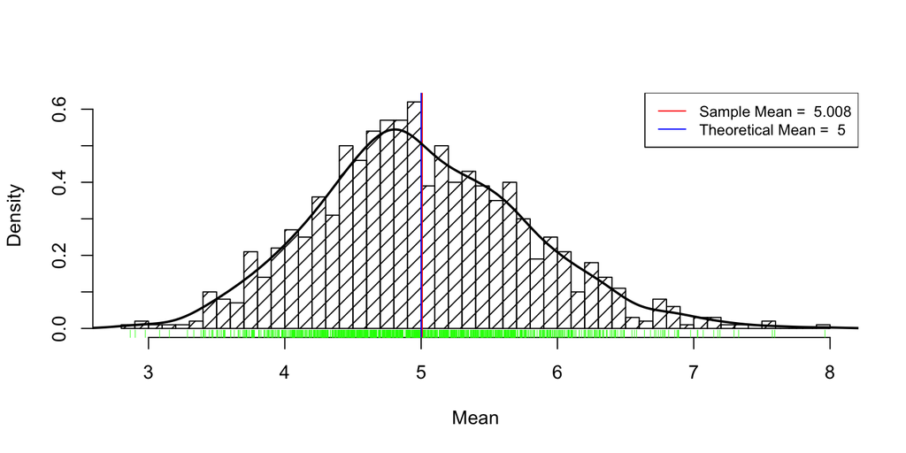